# Analyses

DENIS Anaïs, HOTTLET Valentin, PEREZ Lucie

2024-05-12

packages nécessaires:

```r
library(tidyr)
library(dplyr)
```

```r
library(ggplot2)
library(UpSetR)
```

Récupération et traitement des données, la variable `data` contient nos données brutes et `data_clean` contient les données en ne prenant pas en compte les DATA_ERROR ni les NA.

```r
data <- read.csv('C:/Users/val92/PycharmProjects/Projet-antibio/results/table.csv')

antibiotiques <- names(data)[4:ncol(data)]
data_noerror <- data %>%
  mutate(across(.cols = starts_with(antibiotiques), ~na_if(., "DATA_ERROR")))


data_clean <- data_noerror %>%
  rowwise() %>%
  filter(sum(!is.na(c_across(all_of(antibiotiques)))) > 0) %>%
  ungroup()
```

Nombre de génomes testés :

```r
nombre_genomes <- nrow(data_clean) - 1
nombre_genomes
```

```
## [1] 74621
```

Nombre de taxons :

```r
nombre_especes_uniques <- length(unique(data_clean$taxon_id))
nombre_especes_uniques
```

```
## [1] 3232
```

Nombre d’antibiotiques :

```r
nombre_antibiotiques <- ncol(data) - 3
nombre_antibiotiques
```

```
## [1] 166
```

Nombre de génomes pour chaque taxon :

```r
comptage_genomes <- aggregate(genome_id ~ taxon_id, data = data_clean, FUN = function(x) length(unique(x)))

names(comptage_genomes) <- c("taxon_id", "nombre_genomes")
print(comptage_genomes)
```

```
##      taxon_id nombre_genomes
## 1         195            370
## 2         197            489
## 3         210             53
## 4         287           1073
## 5         316             19
## 6         470           1360
## 7         471              1
## 8         485           4766
## 9         487             33
## 10        545              2
## 11        546             10
## 12        548             93
## 13        550            328
## 14        562           8108
```

[output cut: 3218 more lines]

Moyenne et médiane du nombre de génomes testés pour chaque taxon :

```r
# Calculer la moyenne et la médiane
moyenne <- mean(comptage_genomes$nombre_genomes)
mediane <- median(comptage_genomes$nombre_genomes)

print(paste("Moyenne :", moyenne))
```

```
## [1] "Moyenne : 22.8332301980198"
```

```r
print(paste("Médiane :", mediane))
```

```
## [1] "Médiane : 1"
```

Nombre d’antibiotiques testés pour chaque taxon :

```r
#Obtenir la liste des taxons_id différents
taxons_ids <- unique(data_clean$taxon_id)

nombre_antibiotiques_testes <- numeric(length(taxons_ids))

# Parcourir chaque taxon_id
for (i in seq_along(taxons_ids)) {
  # Extraire les lignes correspondant au taxon_id actuel
  subset_data <- data[data_clean$taxon_id == taxons_ids[i], ]

  # Initialiser un vecteur pour stocker les résultats pour chaque colonne
  resultats_colonnes <- logical(ncol(subset_data) - 3)

  # Parcourir chaque colonne de la 4ème à la dernière
  for (j in 4:ncol(subset_data)) {
    resultats_colonnes[j - 3] <- any(!is.na(subset_data[, j]))
  }

  # Ajouter 1 au nombre d'antibiotiques testés si au moins une colonne a un élément non-NA
  nombre_antibiotiques_testes[i] <- sum(resultats_colonnes)
}

resultats <- data.frame(taxon_id = taxons_ids, nombre_antibiotiques_testes = nombre_antibiotiques_testes)

print(resultats)
```

```
##      taxon_id nombre_antibiotiques_testes
## 1      134375                          33
## 2     1310800                          27
## 3     1310784                          19
## 4     1310751                          20
## 5         470                          67
## 6     1310586                          24
## 7     1310571                          20
## 8     1310572                          20
## 9     1310622                          20
## 10    1310554                          20
## 11    1310592                          20
## 12    1310590                          20
## 13    1310831                          20
## 14    1310574                          19
```

[output cut: 3218 more lines]

Moyenne et médiane du nombre d’antibiotiques testés pour chaque taxon :

```r
# Calculer la moyenne et la médiane
moyenne <- mean(resultats$nombre_antibiotiques_testes)
mediane <- median(resultats$nombre_antibiotiques_testes)

print(paste("Moyenne :", moyenne))
```

```
## [1] "Moyenne : 8.57023514851485"
```

```r
print(paste("Médiane :", mediane))
```

```
## [1] "Médiane : 6"
```

graphique montrant les taxons_id ayant le plus de génomes testés.

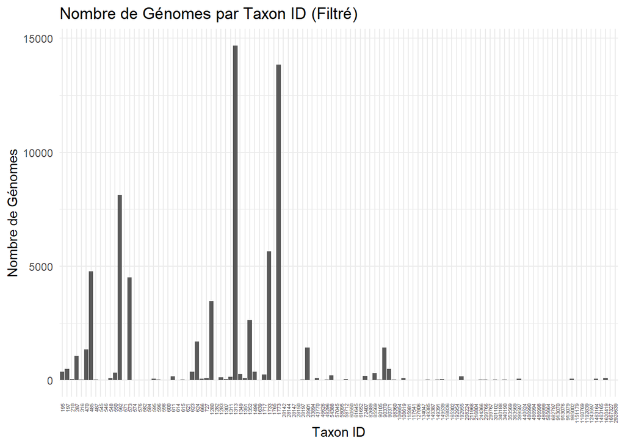

```r
comptage_genomes_filtre <- comptage_genomes[comptage_genomes$nombre_genomes > 1,]

comptage_genomes_filtre$taxon_id <- factor(comptage_genomes_filtre$taxon_id)


ggplot(comptage_genomes_filtre, aes(x = taxon_id, y = nombre_genomes)) +
  geom_bar(stat = "identity") +
  theme_minimal() +
  labs(title = "Nombre de Génomes par Taxon ID (Filtré)",
       x = "Taxon ID",
       y = "Nombre de Génomes") +
  theme(axis.text.x = element_text(angle = 90, hjust = 1, vjust = 0.5, size = 4))
```

Graphique présentant les taxons_id les plus testés (=> 20) :

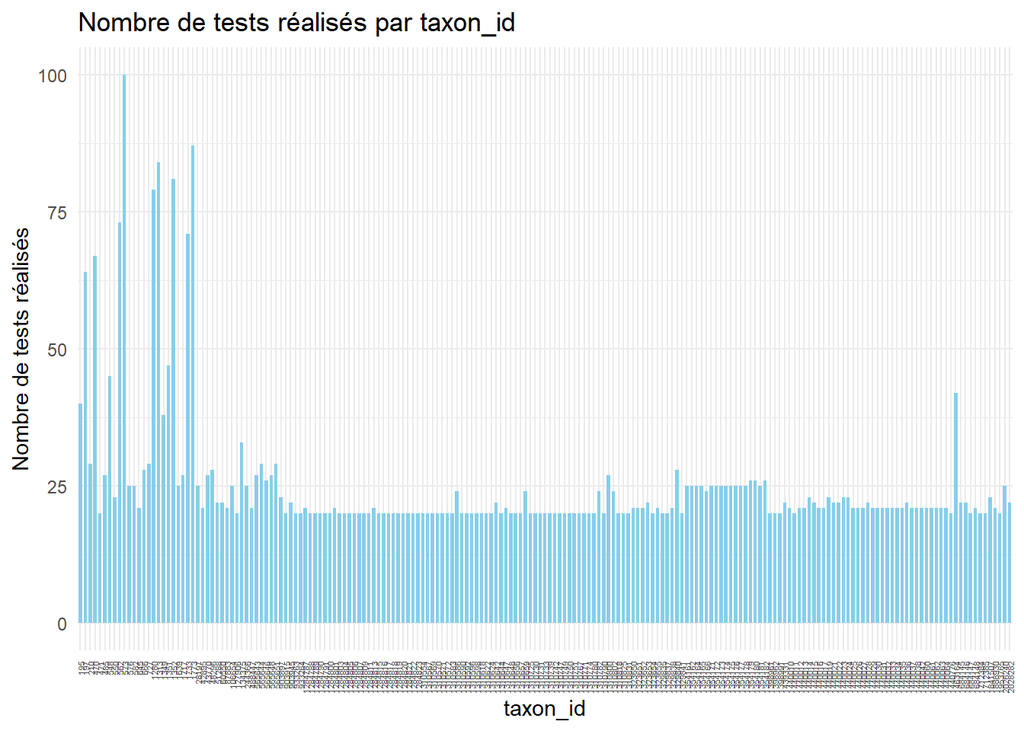

```r
resultats_filtres <- resultats[resultats$nombre_antibiotiques_testes >= 20, ]
# Créer un graphique à barres avec espacement entre les taxons_id
ggplot(resultats_filtres, aes(x = factor(taxon_id), y = nombre_antibiotiques_testes)) +
  geom_bar(stat = "identity", fill = "skyblue", width = 0.7, ) +
  labs(x = "taxon_id", y = "Nombre de tests réalisés") +
  ggtitle("Nombre de tests réalisés par taxon_id") +
  theme_minimal() +
  theme(axis.text.x = element_text(angle = 90, hjust = 1, vjust = 0.5, size = 4))
```

Les valeurs de résistance sont normalisées : R (Resistant, Non susceptible), I (Intermediate, Reduced Susceptibility), S (Susceptible, IS, Susceptible-dose dependent)

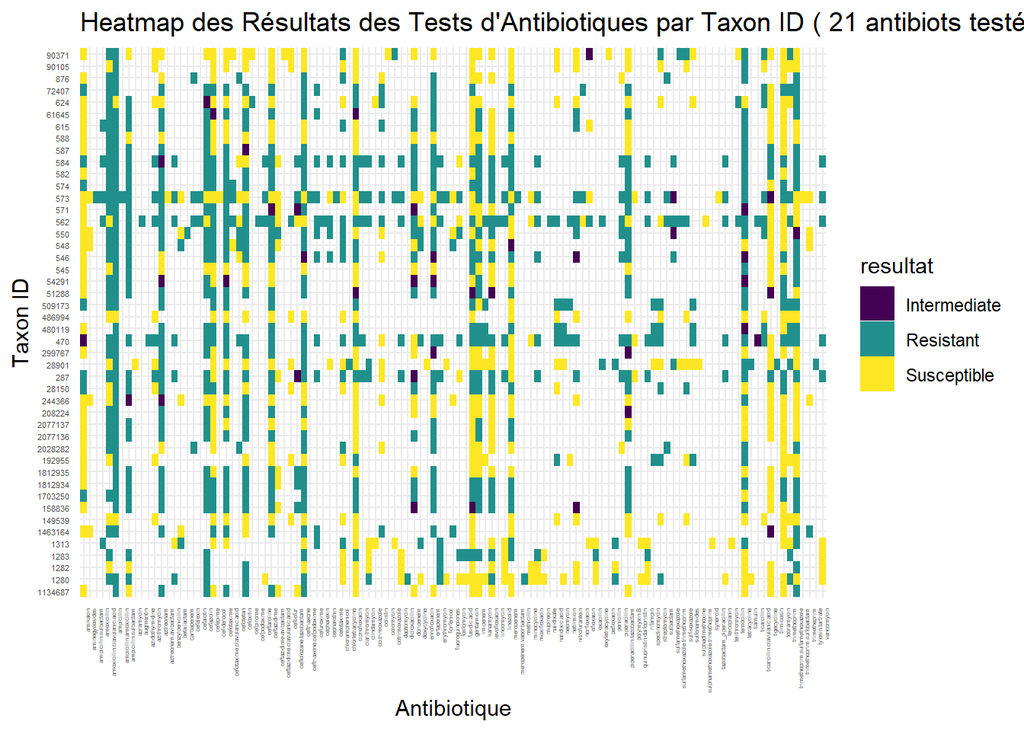

```r
library(tidyr)
library(dplyr)

donnees_longues <- pivot_longer(
  data_noerror,
  cols = all_of(antibiotiques),
  names_to = "antibiotique",
  values_to = "resultat",
  values_drop_na = TRUE
)

donnees_longues$taxon_id <- as.character(donnees_longues$taxon_id)

donnees_longues <- donnees_longues %>%
  mutate(resultat = case_when(
    resultat == "IS" | resultat == "Susceptible-dose dependent" ~ "Susceptible",
    TRUE ~ as.character(resultat)
  ))

donnees_longues <- donnees_longues %>%
  mutate(resultat = case_when(
    resultat == "Nonsusceptible" ~ "Resistant",
    TRUE ~ as.character(resultat)
  ))

donnees_longues <- donnees_longues %>%
  mutate(resultat = case_when(
    resultat == "Reduced Susceptibility" ~ "Intermediate",
    TRUE ~ as.character(resultat)
  ))



taxons_frequents <- donnees_longues %>%
  group_by(taxon_id) %>%
  summarise(n_tests = n_distinct(antibiotique)) %>%
  filter(n_tests > 21)

# Filtrer les données longues pour ne conserver que les taxons répondant au critère.
donnees_filtrees <- donnees_longues %>%
  filter(taxon_id %in% taxons_frequents$taxon_id)

# Créer la heatmap avec les données filtrées.
ggplot(donnees_filtrees, aes(x = antibiotique, y = taxon_id, fill = resultat)) +
  geom_tile() + # Utilise les cases pour représenter les données
  scale_fill_viridis_d() + # Utilise une palette de couleurs pour des données discrètes
  labs(title = "Heatmap des Résultats des Tests d'Antibiotiques par Taxon ID ( 21 antibiots testés)",
       x = "Antibiotique",
       y = "Taxon ID") +
  theme_minimal() +
  theme(axis.text.x = element_text(angle = 90, hjust = 1, size = 3), axis.text.y = element_text(size = 4))# Rotation des étiquettes pour la lisibilité
```

Représentation globale de la susceptibilité des taxon_id contre un antibiotique. (heatmap, global)

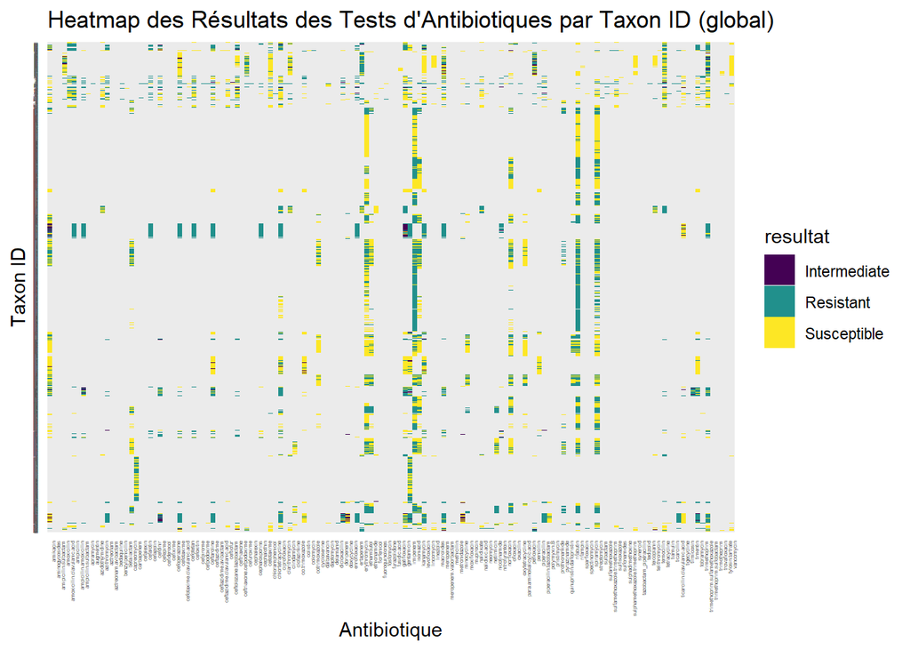

```r
taxons_frequents <- donnees_longues %>%
  group_by(taxon_id) %>%
  summarise(n_tests = n_distinct(antibiotique)) %>%
  filter(n_tests > 1)

# Filtrer les données longues pour ne conserver que les taxons répondant au critère.
donnees_filtrees <- donnees_longues %>%
  filter(taxon_id %in% taxons_frequents$taxon_id)

# Créer la heatmap avec les données filtrées.
ggplot(donnees_filtrees, aes(x = antibiotique, y = taxon_id, fill = resultat)) +
  geom_tile() + # Utilise les cases pour représenter les données
  scale_fill_viridis_d() + # Utilise une palette de couleurs pour des données discrètes
  labs(title = "Heatmap des Résultats des Tests d'Antibiotiques par Taxon ID (global)",
       x = "Antibiotique",
       y = "Taxon ID") +
  theme_minimal() +
  theme(axis.text.x = element_text(angle = 90, hjust = 1, size = 3), axis.text.y = element_text(size = 0.1))# Rotation des étiquettes pour la lisibilité
```

Nombre de données manquantes (DATA_ERROR) dans le fichier de données.

```r
all_data <- pivot_longer(
  data,
  cols = all_of(antibiotiques),
  names_to = "antibiotique",
  values_to = "resultat",
)

total_data_error <- all_data %>%
  filter(resultat == "DATA_ERROR") %>%
  summarise(count = n())
print(total_data_error)
```

```
## # A tibble: 1 × 1
##    count
##    <int>
## 1 155524
```

Tableau présentant le nombre de DATA_ERROR par taxon_ID

```r
data_error_par_taxon <- all_data %>%
  filter(resultat == "DATA_ERROR") %>%
  group_by(taxon_id) %>%
  summarise(count = n()) %>%
  ungroup()
print(data_error_par_taxon)
```

```
## # A tibble: 554 × 2
##    taxon_id count
##       <dbl> <int>
##  1      195   174
##  2      197     6
##  3      287   138
##  4      470  1470
##  5      485 25906
##  6      487    17
##  7      545     4
##  8      546     5
##  9      548   608
## 10      550  7096
## # ℹ 544 more rows
```

Moyenne et médiane du nombre de DATA_ERROR pour chaque taxon :

```r
# Calculer la moyenne et la médiane
moyenne <- mean(data_error_par_taxon$count)
mediane <- median(data_error_par_taxon$count)

print(paste("Moyenne :", moyenne))
```

```
## [1] "Moyenne : 280.729241877256"
```

```r
print(paste("Médiane :", mediane))
```

```
## [1] "Médiane : 11"
```